# Self-Driving Car Engineer Nanodegree

## Project: Build a Traffic Sign Recognition Classifier

This Jupyter notebook contains the code pipeline for a traffic sign classifier tuned for project 2 of Term 1. Python libraries used in this project:

- `pickle`: save and load binary python objects
- `numpy`: algebra calculations
- `matplotlib`: plots and image loading
- `tensorflow`: machine learning framework
- `sklearn`: machine learning framework

Packages `scikit-image` and `cv2` were tested, but not used in final form.

## Step 0: Load The Data

Input data was provided in binary files.

```python
# Load pickled data
import pickle
import numpy as np

training_file = './traffic-signs-data/train.p'
validation_file= './traffic-signs-data/valid.p'
testing_file = './traffic-signs-data/test.p'

with open(training_file, mode='rb') as f:
    train = pickle.load(f)
with open(validation_file, mode='rb') as f:
    valid = pickle.load(f)
with open(testing_file, mode='rb') as f:
    test = pickle.load(f)

X_train0, y_train0 = train['features'], train['labels']
X_valid0, y_valid0 = valid['features'], valid['labels']
X_test0, y_test0 = test['features'], test['labels']
```

## Step 1: Dataset Summary & Exploration

The pickled data is a dictionary with 4 key/value pairs:

- `'features'` is a 4D array containing raw pixel data of the traffic sign images, (num examples, width, height, channels).
- `'labels'` is a 1D array containing the label/class id of the traffic sign. The file `signnames.csv` contains id -> name mappings for each id.

### Basic Summary of the Data Set Using Python and Numpy

```python
# Number of training examples
n_train = X_train0.shape[0]

# Number of validation examples
n_validation = X_valid0.shape[0]

# Number of testing examples.
n_test = X_test0.shape[0]

# What's the shape of an traffic sign image?
image_shape = X_train0.shape[1], X_train0.shape[2], X_train0.shape[3]

# How many unique classes/labels there are in the dataset.
n_classes = np.max(np.unique(y_train0).shape)

print("Number of training examples =", n_train)
print("Number of validation examples =", n_validation)
print("Number of testing examples =", n_test)
print("Image data shape =", image_shape)
print("Number of classes =", n_classes)
print("labels shape: ", y_train0.shape)
print(y_train0[0:4])
```

```
Number of training examples = 34799
Number of validation examples = 4410
Number of testing examples = 12630
Image data shape = (32, 32, 3)
Number of classes = 43
labels shape:  (34799,)
[41 41 41 41]
```

### Visualization of the dataset

Next, it is presented 4 random images from the training dataset and a histogram of labels (output).

```
19370 13165 4895 26662
```

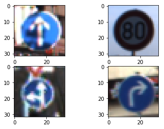

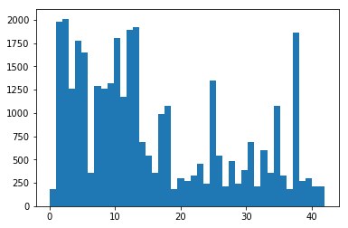

```python
### Data exploration visualization code goes here.
import matplotlib.pyplot as plt
import matplotlib.image as mpimg
# Visualizations will be shown in the notebook.
%matplotlib inline

im1 = np.round(np.random.random_sample()*n_train).astype(int)
im2 = np.round(np.random.random_sample()*n_train).astype(int)
im3 = np.round(np.random.random_sample()*n_train).astype(int)
im4 = np.round(np.random.random_sample()*n_train).astype(int)

print(im1, im2, im3, im4)

fig, axs = plt.subplots(nrows=2, ncols=2)
axs[0, 0].imshow(X_train0[im1,:,:,:])
axs[0, 1].imshow(X_train0[im2,:,:,:])
axs[1, 0].imshow(X_train0[im3,:,:,:])
axs[1, 1].imshow(X_train0[im4,:,:,:])

plt.show()

plt.figure()
plt.hist(train['labels'], n_classes)
```

Labels in the training set are not equally distributed.

## Step 2: Design and Test a Model Architecture

The architecture proposed here adds another fully connected layer and uses a deeper convolutional filter.

### Pre-process the Data Set

Pre-processing is made in two steps:

- grayscaling with: Gray = 0.299 Red + 0.587 Green + 0.114 Blue
- normalizing pixel intensity

```
max min  -0.488235294118 0.5
Normalized grayscaled images.
```

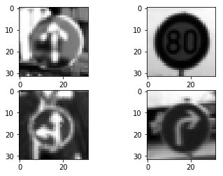

```
Done preprocessing.
```

```python
### Preprocess the data here.
from sklearn.utils import shuffle
#from skimage import exposure
#from skimage.color import rgb2gray
from datetime import datetime

# training data
X_train = np.zeros((n_train, X_train0.shape[1], X_train0.shape[2], 1), np.int)

# validation data
X_valid = np.zeros((n_validation, X_valid0.shape[1], X_valid0.shape[2], 1), np.int)

# grayscale luminosity
#lum = np.ndarray((3,), np.float, np.array([0.210, 0.720, 0.070]))
lum = np.ndarray((3,), np.float, np.array([0.299, 0.587, 0.114]))

y_train = y_train0
y_valid = y_valid0

for i in range(n_train):
    # grayscale with CV2
    #X_train[i,:,:,:] = cv2.cvtColor(X_train[i,:,:,:], cv2.COLOR_RGB2GRAY)
    # grayscale with luminosity
    # 0.21 R + 0.72 G + 0.07 B.
    #X_train[i,:,:,0] = (X_train1[i,:,:,0]*0.21 + X_train1[i,:,:,1]*0.72 + X_train1[i,:,:,2]*0.07).astype(int)
    # also suggested in CarND online foruns
    #X_train[i,:,:,0] = np.dot(X_train1[i,:,:,:], lum).astype(int)
    #p2, p98 = np.percentile(X_train1[i,:,:,:], (2, 98))
    #X_train1[i,:,:,:] = exposure.rescale_intensity(X_train1[i,:,:,:], in_range=(p2, p98))
    #pass
    #X_train[i,:,:,0] = np.dot(X_train1[i,:,:,:]
    #X_train[i,:,:,0] = rgb2gray(X_train1[i,:,:,:])

    # grayscale
    X_train[i,:,:,0] = np.dot(X_train0[i,:,:,:], lum)


for i in range(n_validation):
    X_valid[i,:,:,0] = np.dot(X_valid0[i,:,:,:], lum).astype(int)

# normalized after grayscale and save computing costs
X_train = (X_train/255.0)-0.5
X_valid = (X_valid/255.0)-0.5

# check data
print("max min ",np.amin(X_train), np.amax(X_train))

fig, axs = plt.subplots(nrows=2, ncols=2)
axs[0, 0].imshow(X_train[im1,:,:,0], cmap=plt.cm.gray)
axs[0, 1].imshow(X_train[im2,:,:,0], cmap=plt.cm.gray)
axs[1, 0].imshow(X_train[im3,:,:,0], cmap=plt.cm.gray)
axs[1, 1].imshow(X_train[im4,:,:,0], cmap=plt.cm.gray)

print("Normalized grayscaled images.")
plt.show()

print("Done preprocessing.")
```

### Model Architecture

The python function which creates the logitis was coded with a factory pattern, a form of closure. This makes it reusable with different number of output classes.

```python
import tensorflow as tf
from tensorflow.contrib.layers import flatten
from tensorflow.python.client import device_lib

import platform

def factory(n_classes, mu = 0, sigma = 0.1):

    def LeNet(x):

        # W=32, F=5, P=0, S=1
        # out = 1 + [W-F+2P]/S  => 1 + (32-5+0)/1 = 28
        # Input = 32x32x1. Output = 28x28x6.
        # number of filters is arbitrary
        # https://discussions.udacity.com/t/define-input-depth-output-depth-f/238575/14
        #
        conv1_W = tf.Variable(tf.truncated_normal(shape=(5, 5, 1, 16), mean = mu, stddev = sigma))
        conv1_b = tf.Variable(tf.zeros(16))
        conv1   = tf.nn.conv2d(x, conv1_W, strides=[1, 1, 1, 1], padding='VALID') + conv1_b

        # Activation.
        conv1 = tf.nn.relu(conv1)

        # out = 1 + [W-F+2P]/S  => 1+(28-2+0)/2 = 14
        # Pooling. Input = 28x28x16, Output = 14x14x16.
        conv1 = tf.nn.max_pool(conv1, ksize=[1, 2, 2, 1], strides=[1, 2, 2, 1], padding='VALID')

        # out = 1 + [W-F+2P]/S  => 1+(14-5+0)/1 = 10
        # Layer 2: Convolutional. Input = 14x14x16, Output = 10x10x32.
        conv2_W = tf.Variable(tf.truncated_normal(shape=(5, 5, 16, 32), mean = mu, stddev = sigma))
        conv2_b = tf.Variable(tf.zeros(32))
        conv2   = tf.nn.conv2d(conv1, conv2_W, strides=[1, 1, 1, 1], padding='VALID') + conv2_b

        # Activation.
        conv2 = tf.nn.relu(conv2)

        # out = 1 + [W-F+2P]/S  => 1+(10-2+0)/2 = 5
        # Pooling. Input = 10x10x16, Output = 5x5x32.
        conv2 = tf.nn.max_pool(conv2, ksize=[1, 2, 2, 1], strides=[1, 2, 2, 1], padding='VALID')

        # Flatten. Input = 5x5x32. Output = 800.
        fc0   = flatten(conv2)

        # out = 1 + [W-F+2P]/S  =>
        # Fully Connected. Input = 800. Output = 400.
        fc1_W = tf.Variable(tf.truncated_normal(shape=(800, 400), mean = mu, stddev = sigma))
        fc1_b = tf.Variable(tf.zeros(400))
        fc1   = tf.matmul(fc0, fc1_W) + fc1_b

        # Activation.
        fc1    = tf.nn.relu(fc1)

        # connected layer
        fc2_W = tf.Variable(tf.truncated_normal(shape=(400, 129), mean = mu, stddev = sigma))
        fc2_b = tf.Variable(tf.zeros(129))
        fc2    = tf.matmul(fc1, fc2_W) + fc2_b

        fc2    = tf.nn.relu(fc2)

        # Fully Connected. Input = 129. Output = 86.
        fc3_W  = tf.Variable(tf.truncated_normal(shape=(129, 86), mean = mu, stddev = sigma))
        fc3_b  = tf.Variable(tf.zeros(86))
        fc3    = tf.matmul(fc2, fc3_W) + fc3_b

        # Activation.
        fc3    = tf.nn.relu(fc3)

        # Input = 86 Output = n_classes.
        fc4_W  = tf.Variable(tf.truncated_normal(shape=(86, n_classes), mean = mu, stddev = sigma))
        fc4_b  = tf.Variable(tf.zeros(n_classes))

        # final
        logits = tf.matmul(fc3, fc4_W) + fc4_b

        return logits
    return LeNet
```

### Train, Validate and Test the Model

Input data was already split into training, validation and testing. This separation helps to prevent overfiting.

```python
def evaluate(X_data, y_data):
    num_examples = len(X_data)
    total_accuracy = 0
    total_loss = 0
    sess = tf.get_default_session()
    for offset in range(0, num_examples, BATCH_SIZE):
        batch_x, batch_y = X_data[offset:offset+BATCH_SIZE], y_data[offset:offset+BATCH_SIZE]
        loss, accuracy = sess.run([loss_operation, accuracy_operation], feed_dict={x: batch_x, y: batch_y})
        total_loss += (loss*len(batch_x))
        total_accuracy += (accuracy * len(batch_x))
    return total_loss/num_examples, total_accuracy / num_examples
```

```python
### Training pipeline

x = tf.placeholder(tf.float32, (None, 32, 32, 1))
y = tf.placeholder(tf.int32, (None))
one_hot_y = tf.one_hot(y, n_classes)

EPOCHS = 50
BATCH_SIZE = 128
#BATCH_SIZE = 256
rate = 0.0005

LeNetFn = factory(n_classes)
logits = LeNetFn(x)
cross_entropy = tf.nn.softmax_cross_entropy_with_logits(labels=one_hot_y, logits=logits)
loss_operation = tf.reduce_mean(cross_entropy)
optimizer = tf.train.AdamOptimizer(learning_rate = rate)
training_operation = optimizer.minimize(loss_operation)

correct_prediction = tf.equal(tf.argmax(logits, 1), tf.argmax(one_hot_y, 1))
accuracy_operation = tf.reduce_mean(tf.cast(correct_prediction, tf.float32))
saver = tf.train.Saver()

print("System:  ")
print(platform.uname())
print("")
devices = [x.name for x in device_lib.list_local_devices() if x.device_type == 'GPU']
print(devices)
print("")

acc_epochs = np.zeros((EPOCHS,), np.float)
loss_fn = np.zeros((EPOCHS,), np.float)
```

```
System:
uname_result(system='Linux', node='ip-172-31-32-67', release='4.4.0-97-generic', version='#120-Ubuntu SMP Tue Sep 19 17:28:18 UTC 2017', machine='x86_64', processor='x86_64')

['/gpu:0']
```

```python
with tf.Session() as sess:
    sess.run(tf.global_variables_initializer())
    num_examples = len(X_train)

    print(datetime.now().isoformat(' '), " - Training...")
    print()
    for i in range(EPOCHS):
        X_train, y_train = shuffle(X_train, y_train)
        for offset in range(0, num_examples, BATCH_SIZE):
            end = offset + BATCH_SIZE
            batch_x, batch_y = X_train[offset:end], y_train[offset:end]
            sess.run(training_operation, feed_dict={x: batch_x, y: batch_y})

        #loss, validation_accuracy = evaluate(X_valid, y_valid)
        loss, validation_accuracy = evaluate(X_train, y_train)
        print("EPOCH {} ...".format(i+1))
        print("Validation Accuracy = {:.3f}".format(validation_accuracy))
        print()
        acc_epochs[i] = validation_accuracy
        loss_fn[i] = loss

    print(datetime.now().isoformat(' '), " - Finished training")
    saver.save(sess, './lenet/lenet')
    print("Model saved")
```

```
2017-10-13 23:16:19.360643  - Training...

EPOCH 1 ...
Validation Accuracy = 0.832

EPOCH 2 ...
Validation Accuracy = 0.912

EPOCH 3 ...
Validation Accuracy = 0.941

EPOCH 4 ...
Validation Accuracy = 0.972

EPOCH 5 ...
Validation Accuracy = 0.985

EPOCH 6 ...
Validation Accuracy = 0.987

EPOCH 7 ...
Validation Accuracy = 0.988

EPOCH 8 ...
Validation Accuracy = 0.992

EPOCH 9 ...
Validation Accuracy = 0.993

EPOCH 10 ...
Validation Accuracy = 0.994

EPOCH 11 ...
Validation Accuracy = 0.995

EPOCH 12 ...
Validation Accuracy = 0.995

EPOCH 13 ...
Validation Accuracy = 0.998
```

[output cut: 99 more lines]

```

EPOCH 47 ...
Validation Accuracy = 1.000

EPOCH 48 ...
Validation Accuracy = 1.000

EPOCH 49 ...
Validation Accuracy = 1.000

EPOCH 50 ...
Validation Accuracy = 1.000

2017-10-13 23:20:04.733339  - Finished training
Model saved
```

```
Average accuracy:  0.990127302522  highest acc:  1.0
```

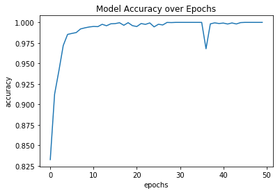

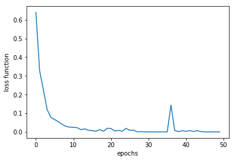

```python
model_r_max = np.max(acc_epochs)
print("Average accuracy: ", np.mean(acc_epochs), " highest acc: ", model_r_max)
plt.figure()
plt.plot(acc_epochs)
plt.xlabel("epochs")
plt.ylabel("accuracy")
plt.title("Model Accuracy over Epochs")
plt.show()
plt.savefig("./output/train_evolution_1FD32_L5_E"+str(EPOCHS)+"_B"+str(BATCH_SIZE)+"_R"+str(rate)+"_A999.png")

plt.figure()
plt.plot(loss_fn)
plt.xlabel("epochs")
plt.ylabel("loss function")
plt.show()
plt.savefig("./output/train_loss_1FD32_L5_E"+str(EPOCHS)+"_B"+str(BATCH_SIZE)+"_R"+str(rate)+"_A999.png")
```

```python
print("Validating: ")
with tf.Session() as sess:
    saver.restore(sess, tf.train.latest_checkpoint('./lenet'))

    _, test_accuracy = evaluate(X_valid, y_valid)
    print("Valid Accuracy = {:.3f}".format(test_accuracy))
```

```
Validating:
INFO:tensorflow:Restoring parameters from ./lenet/lenet
Valid Accuracy = 0.953
```

# Evaluate

After training and validating, its time to test the model with "new" data. This data set was provided in a separated file, so the model was not exposed to it yet.

```python
n_test = X_test0.shape[0]
X_test = np.zeros((n_test, X_test0.shape[1], X_test0.shape[2], 1), np.int)

for i in range(n_test):
    X_test[i,:,:,0] = np.dot(X_test0[i,:,:,:], lum).astype(int)

# normalized after grayscale and save computing costs
X_test = (X_test/255.0)-0.5

with tf.Session() as sess:
    saver.restore(sess, tf.train.latest_checkpoint('./lenet'))

    _, test_accuracy = evaluate(X_test, y_test0)
    print("Test Accuracy = {:.3f}".format(test_accuracy))
```

```
INFO:tensorflow:Restoring parameters from ./lenet/lenet
Test Accuracy = 0.928
```

## Step 3: Test a Model on New Images

Ater testing the model, let's try its accuracy on 5 new images found on internet.

### Load and Output the Images

[figure not shown]

[figure not shown]

```python
import matplotlib.image as mpimg

xtest20 = np.ndarray((5, 32, 32, 3), np.float)
xtest21 = np.ndarray((5, 32, 32, 1), np.float)
#xtest20[0, :, :, :] = mpimg.imread('./new-data/ni_01_14.png')
#xtest20[1, :, :, :] = mpimg.imread('./new-data/ni_02_15.png')
#xtest20[2, :, :, :] = mpimg.imread('./new-data/ni_03_27.png')
#xtest20[3, :, :, :] = mpimg.imread('./new-data/ni_04_30.png')
#xtest20[4, :, :, :] = mpimg.imread('./new-data/ni_05_40.png')

xtest20[0, :, :, :] = mpimg.imread('./new-data/ni_01_14.jpg')
xtest20[1, :, :, :] = mpimg.imread('./new-data/ni_02_15.jpg')
xtest20[2, :, :, :] = mpimg.imread('./new-data/ni_03_27.jpg')
xtest20[3, :, :, :] = mpimg.imread('./new-data/ni_04_30.jpg')
xtest20[4, :, :, :] = mpimg.imread('./new-data/ni_05_40.jpg')

ylabels = np.ndarray((5,), np.int, np.array([14,15,27,30,40]))
lum = np.ndarray((3,), np.float, np.array([0.299, 0.587, 0.114]))
for i in range(5):
    xtest21[i,:,:,0] = np.dot(xtest20[i,:,:,:], lum)

# normalized after grayscale and save computing costs
xtest21 = (xtest21/255.0)-0.5

fig, axs = plt.subplots(nrows=3, ncols=2)
axs[0, 0].imshow(xtest20[0,:,:,:])
axs[0, 1].imshow(xtest20[1,:,:,:])
axs[1, 0].imshow(xtest20[2,:,:,:])
axs[1, 1].imshow(xtest20[3,:,:,:])
axs[2, 0].imshow(xtest20[4,:,:,:])

plt.show()

fig, axs = plt.subplots(nrows=3, ncols=2)
axs[0, 0].imshow(xtest21[0,:,:,0], cmap=plt.cm.gray)
axs[0, 1].imshow(xtest21[1,:,:,0], cmap=plt.cm.gray)
axs[1, 0].imshow(xtest21[2,:,:,0], cmap=plt.cm.gray)
axs[1, 1].imshow(xtest21[3,:,:,0], cmap=plt.cm.gray)
axs[2, 0].imshow(xtest21[4,:,:,0], cmap=plt.cm.gray)

plt.show()
```

### Predict the Sign Type for Each Image

```python
with tf.Session() as sess:
    saver.restore(sess, tf.train.latest_checkpoint('./lenet'))
    r1 = sess.run(logits, feed_dict={x: xtest21})
    print("Logits")
    print(r1)
    print(r1.shape)

    print("")
    print("")
    print("softmax")
    r2 = sess.run(tf.nn.softmax(logits), feed_dict={x: xtest21})
    print(r2)
    print(r2.shape)
    for i in range(5):
        print(i, ylabels[i], r2[i, ylabels[i]])
```

[output not shown]

[output cut: 57 more lines]

[output not shown]

### Analyze Performance

```python
with tf.Session() as sess:
    saver.restore(sess, tf.train.latest_checkpoint('./lenet'))
    _, test_2_accuracy = evaluate(xtest21, ylabels)
    print("Test 2 Accuracy = {:.3f}".format(test_2_accuracy))
```

```
INFO:tensorflow:Restoring parameters from ./lenet/lenet
Test 2 Accuracy = 0.400
```

### Output Top 5 Softmax Probabilities For Each Image Found on the Web

For each of these 5 new images, show the 5 highest probabilities.

```python
with tf.Session() as sess:
    saver.restore(sess, tf.train.latest_checkpoint('./lenet'))

    prob1 = sess.run(tf.nn.top_k(logits, k=5), feed_dict={x: xtest21})
    print(prob1)

    prob2 = sess.run(tf.nn.top_k(tf.nn.softmax(logits), k=5), feed_dict={x: xtest21})
    print(prob2)
```

```
INFO:tensorflow:Restoring parameters from ./lenet/lenet
TopKV2(values=array([[ 25.7023735 ,  10.0042429 ,   7.78945684,   2.82251906,
          1.29654014],
       [ 16.77182198,  15.46515369,  15.17523003,  10.63594723,
          4.63538361],
       [ 29.33576584,  25.44639397,  19.18460464,  10.47777081,  10.3898983 ],
       [ 38.60680771,  26.81198692,  18.42742538,  16.0741806 ,
         15.78407001],
       [  7.95799875,   7.32501936,   5.44001627,   2.98316622,
          1.61104047]], dtype=float32), indices=array([[14,  1, 17, 37,  2],
       [35, 13, 15,  3, 36],
       [ 1, 40, 12, 37,  4],
       [25, 21, 29, 23, 22],
       [40, 12,  9,  7, 32]], dtype=int32))
TopKV2(values=array([[  9.99999881e-01,   1.52190822e-07,   1.66157239e-08,
          1.15719226e-10,   2.51582730e-11],
       [  6.77744985e-01,   1.83479473e-01,   1.37301475e-01,
          1.46652607e-03,   3.63310619e-06],
       [  9.79914486e-01,   2.00472791e-02,   3.82467806e-05,
          6.32798480e-09,   5.79565373e-09],
       [  9.99992490e-01,   7.54346956e-06,   1.72267089e-09,
          1.63757466e-10,   1.22520091e-10],
       [  6.16400123e-01,   3.27313006e-01,   4.96954732e-02,
          4.25912486e-03,   1.07997516e-03]], dtype=float32), indices=array([[14,  1, 17, 37,  2],
       [35, 13, 15,  3, 36],
       [ 1, 40, 12, 37,  4],
       [25, 21, 29, 23, 22],
       [40, 12,  9,  7, 32]], dtype=int32))
```

Model was able to predict only 2 out of 5 images, the first image with 100%. This first image contains the "stop" sign, which is the 14th label. The second was label 40th, Roundabout with 61%.